# Updated Results Diagnostics

### Leaflet length

Best fitted data: Log transformed data

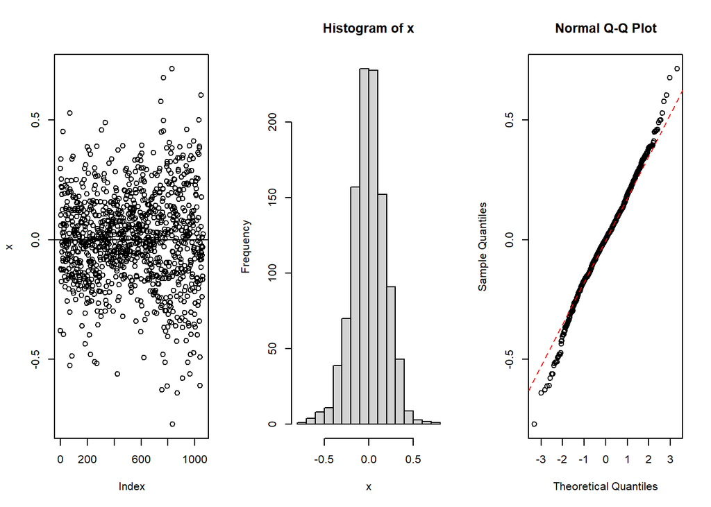

```
## [1] "Kurtosis=0.798536670239446"
## [1] "Skew=-0.132164114832064"
```

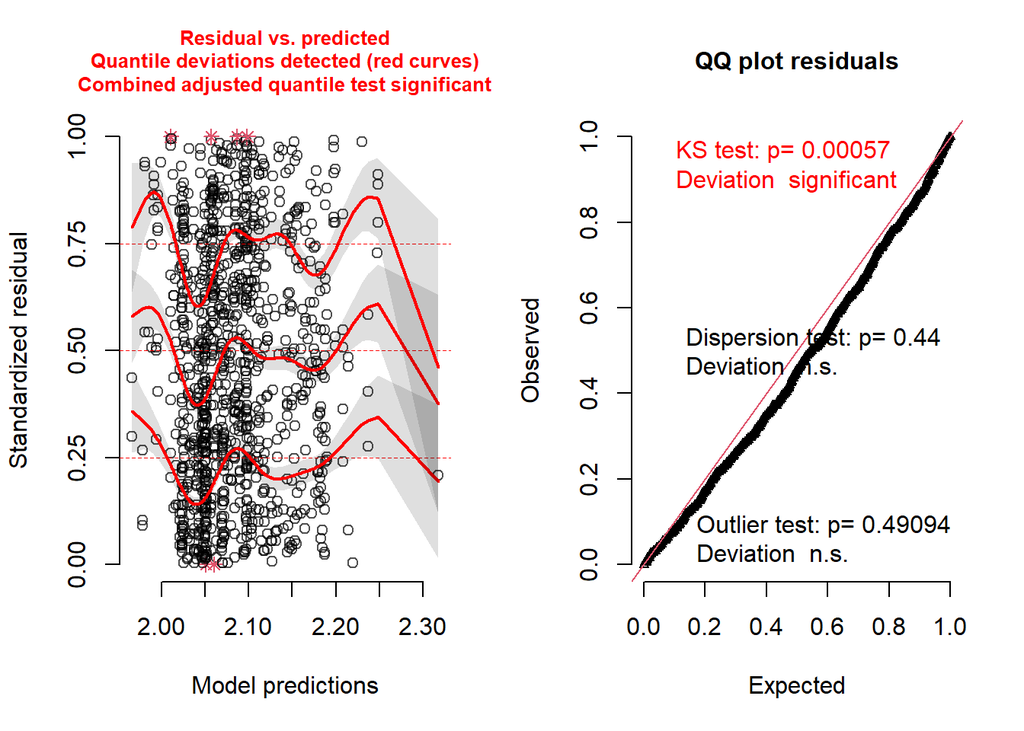

```
## Analysis of Deviance Table (Type II Wald chisquare tests)
##
## Response: log(leaflet_length)
##                  Chisq Df Pr(>Chisq)
## mainland_island 4.8651  1   0.027405 *
## year_collected  8.6928  1   0.003195 **
## ---
## Signif. codes:  0 '***' 0.001 '**' 0.01 '*' 0.05 '.' 0.1 ' ' 1
```

**Mainland and island differences and year differences are significant.**

#### Emmeans: Leaflet length

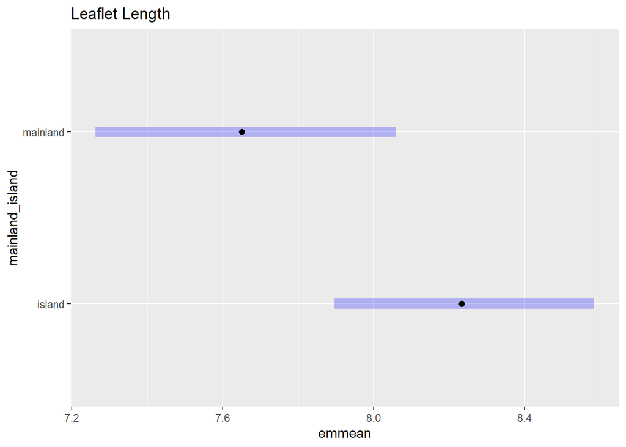

# Model 2: trait ~ galapagos/other + year + (1|ID)

This model looks at the differences between *Tribulus* flowers and leaves from Galapagos and other island systems. We do not have mericarp data from other islands so they are not included.

## Flower traits:

### Petal length

Best fitted data: Squared root data

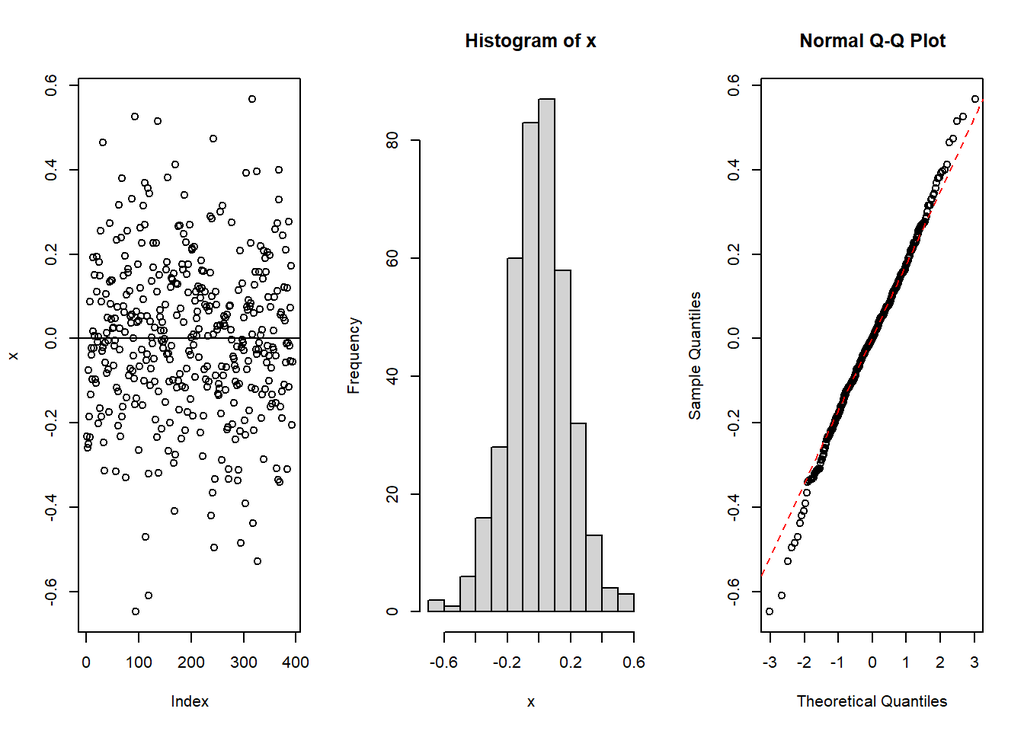

```
## [1] "Kurtosis=0.526417690150699"
## [1] "Skew=-0.114096244913898"
```

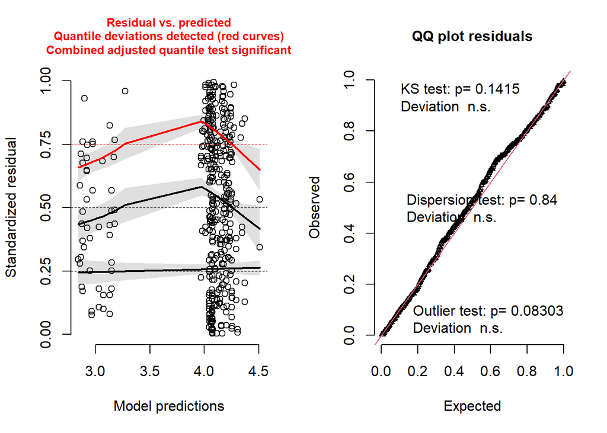

```
## Analysis of Deviance Table (Type II Wald chisquare tests)
##
## Response: sqrt(petal_length)
##                   Chisq Df Pr(>Chisq)
## galapagos_other 156.398  1  < 2.2e-16 ***
## year_collected   10.133  1   0.001456 **
## ---
## Signif. codes:  0 '***' 0.001 '**' 0.01 '*' 0.05 '.' 0.1 ' ' 1
```

#### Emmeans: Petal length

[figure not shown]

## Leaf traits:

### Leaf length

Best fitted data: Log transformed data

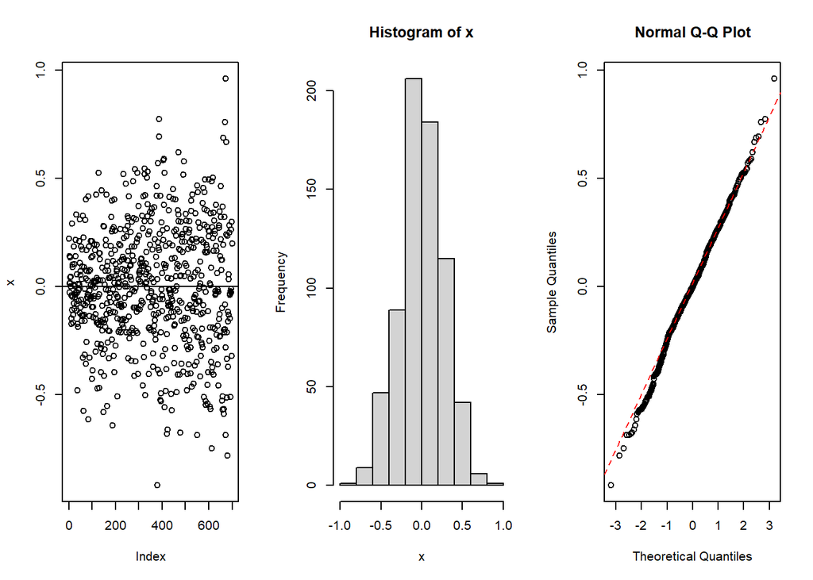

```
## [1] "Kurtosis=0.193135255752809"
## [1] "Skew=-0.0988914986843238"
```

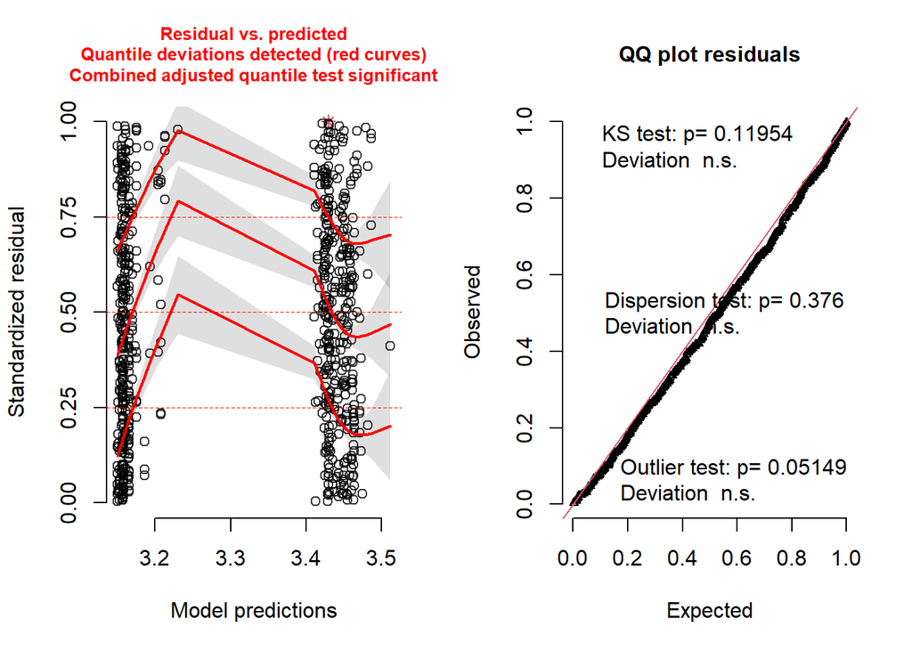

```
## Analysis of Deviance Table (Type II Wald chisquare tests)
##
## Response: log(leaf_length)
##                   Chisq Df Pr(>Chisq)
## galapagos_other 20.3974  1  6.291e-06 ***
## year_collected   0.5726  1     0.4492
## ---
## Signif. codes:  0 '***' 0.001 '**' 0.01 '*' 0.05 '.' 0.1 ' ' 1
```

**Differences between galapagos and other islands are significant**

#### Emmeans: Leaf length

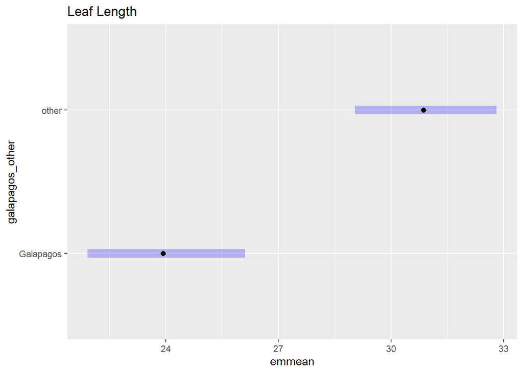

### Leaflet number

For this trait I used a glm model with a Poisson distribution:

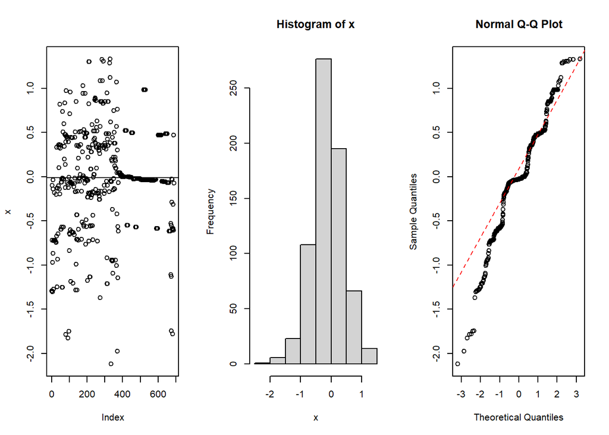

```
## [1] "Kurtosis=1.14450585157219"
## [1] "Skew=-0.450482991123054"
```

[output not shown]

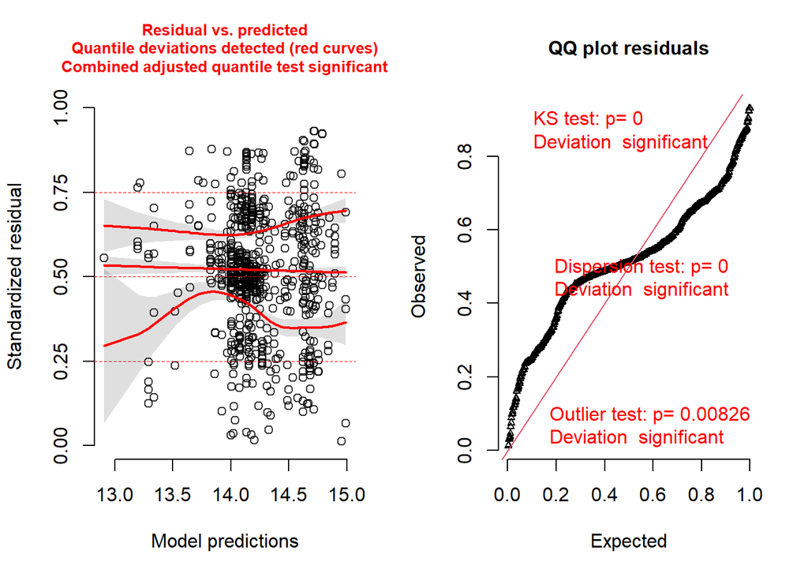

```
## Analysis of Deviance Table (Type II tests)
##
## Response: number_of_leaflets
##                 LR Chisq Df Pr(>Chisq)
## galapagos_other   4.5993  1    0.03198 *
## year_collected    3.2926  1    0.06959 .
## ---
## Signif. codes:  0 '***' 0.001 '**' 0.01 '*' 0.05 '.' 0.1 ' ' 1
```

#### Emmeans: Leaflet number

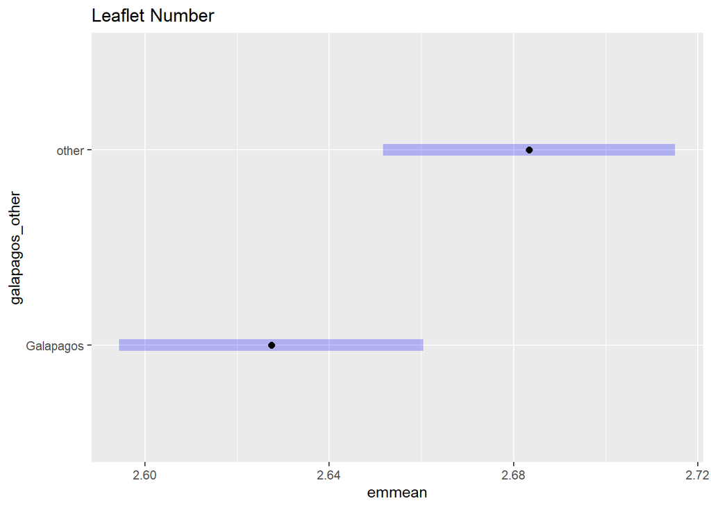

### Leaflet length

Best fitted data: Log transformed data

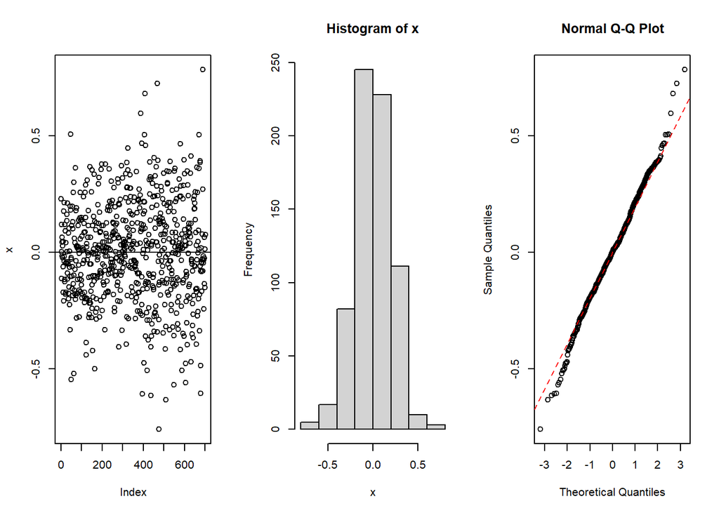

```
## [1] "Kurtosis=0.542906559522408"
## [1] "Skew=-0.0347332872064938"
```

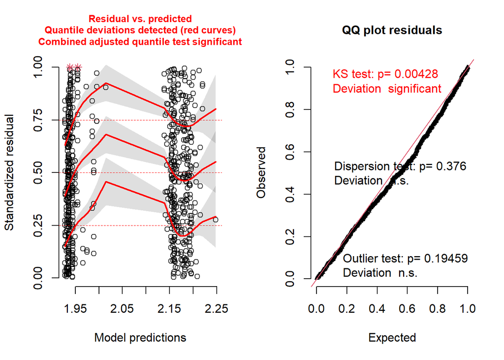

```
## Analysis of Deviance Table (Type II Wald chisquare tests)
##
## Response: log(leaflet_length)
##                   Chisq Df Pr(>Chisq)
## galapagos_other 17.2063  1  3.353e-05 ***
## year_collected   0.8816  1     0.3478
## ---
## Signif. codes:  0 '***' 0.001 '**' 0.01 '*' 0.05 '.' 0.1 ' ' 1
```

**Galapagos and other island differences are significant.**

#### Emmeans: Leaflet length

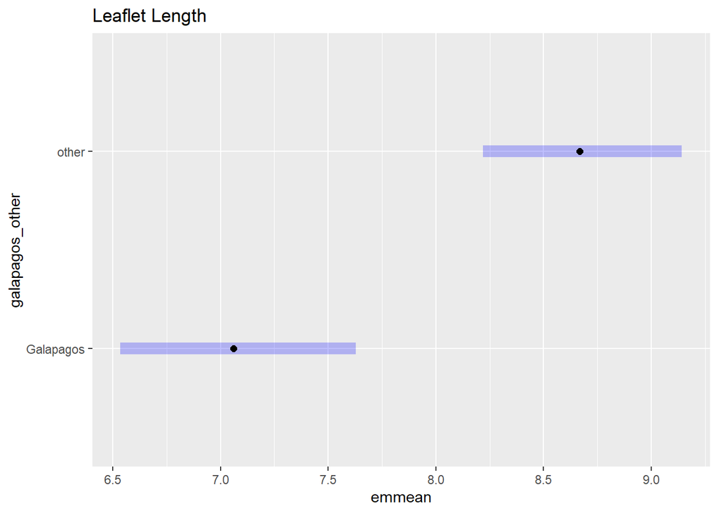

# Model 3: trait ~ finch beak + year + (1|ID)

This model looks at the differences between *Tribulus* mericarps, flowers and leaves within the Galapagos islands that differ in the distribution of seed predators *G. magnirostis* and *G. cornirostris.* Darwin’s finches that are known to easily predate mericarps.

| Presence of *G. magnirostris* and *G. Cornirrostris* | Absence of *G. magnirostris* and *G. Cornirrostris* |
| --- | --- |
| Daphne Major | Floreana |
| Daphne Minor | San Cristobal |
| Darwin | Santa Fe |
| Fernandina | Champion |
| Genovesa | Baltra |
| Guy Fawkes Oeste | Enderby |
| Isabela | Gardner |
| Pinta | Daphne Major <1983 |
| Plaza Norte |  |
| Rabida |  |
| Santa Cruz |  |
| Santiago |  |
| Seymour Norte |  |
| Espanola |  |

## Mericarp traits:

### Length

Best fitted data: Untransformed data

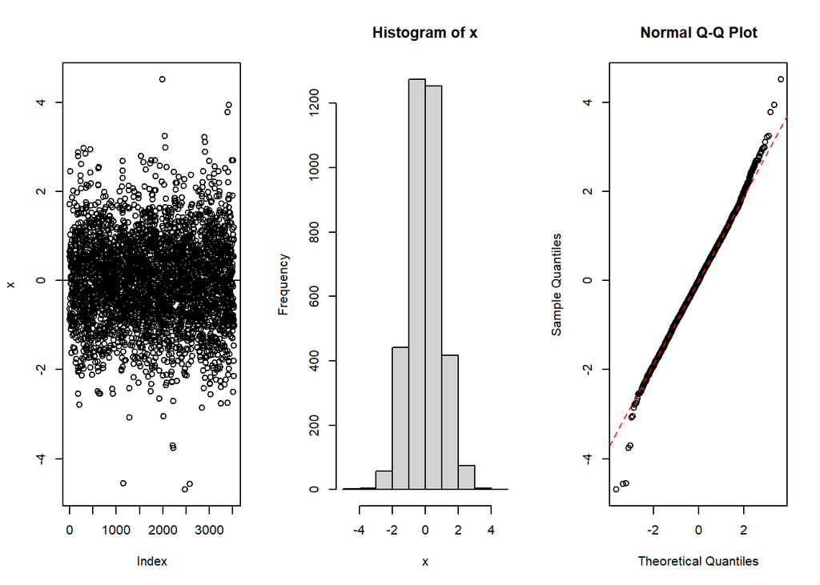

```
## [1] "Kurtosis=0.641070100215158"
## [1] "Skew=0.00706886345866648"
```

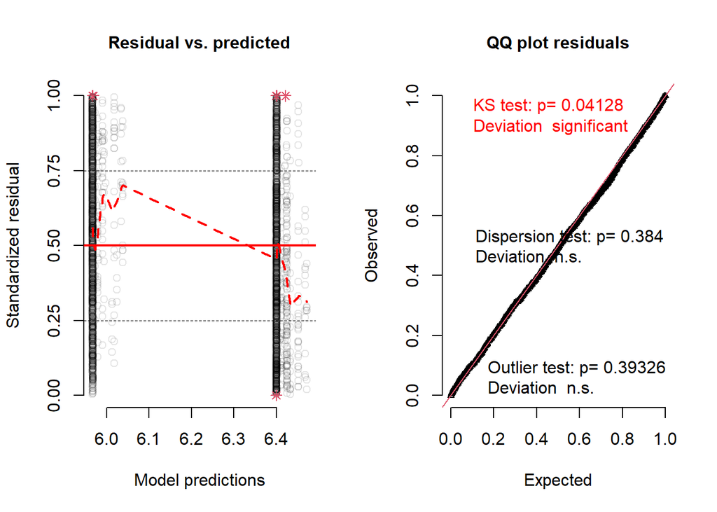

```
## Analysis of Deviance Table (Type II Wald chisquare tests)
##
## Response: length
##                 Chisq Df Pr(>Chisq)
## finch_beak     5.1150  1    0.02372 *
## year_collected 0.0384  1    0.84464
## ---
## Signif. codes:  0 '***' 0.001 '**' 0.01 '*' 0.05 '.' 0.1 ' ' 1
```

#### Emmeans: Length

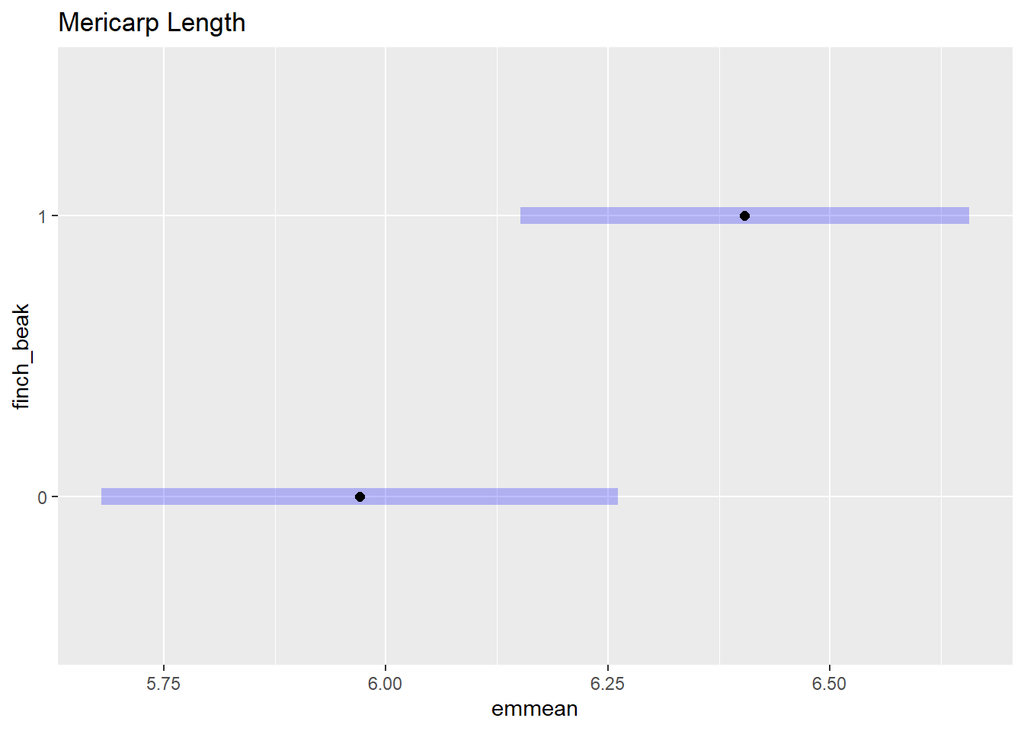

### Width

Best fitted data: Square root transformed data

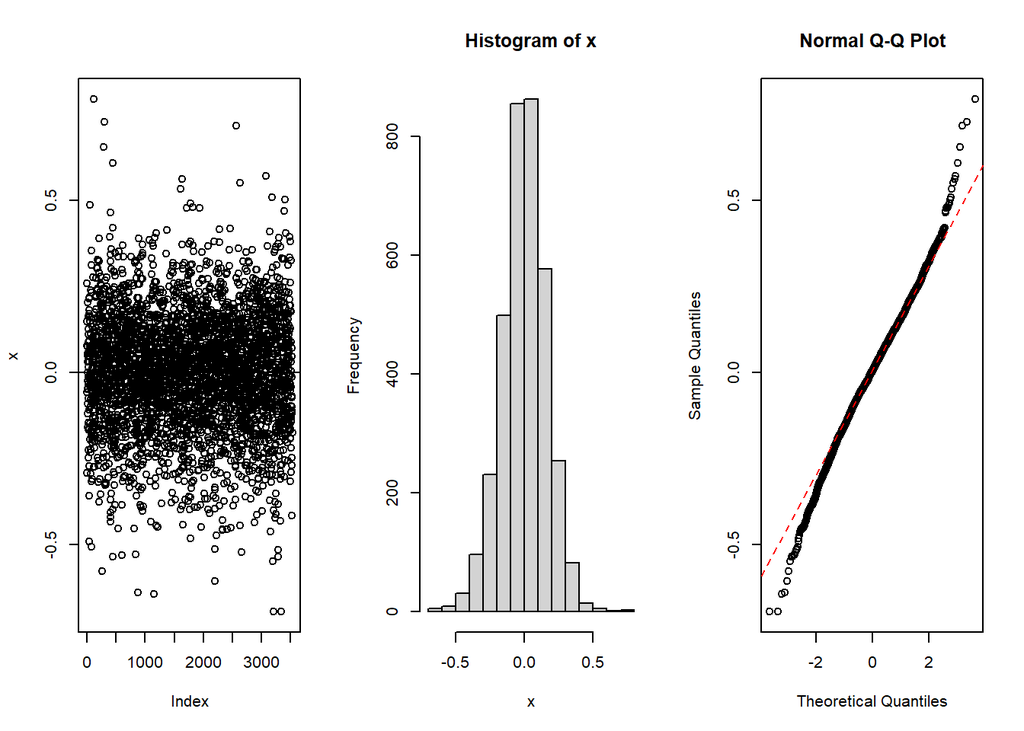

```
## [1] "Kurtosis=0.865895540669791"
## [1] "Skew=-0.131502833504471"
```

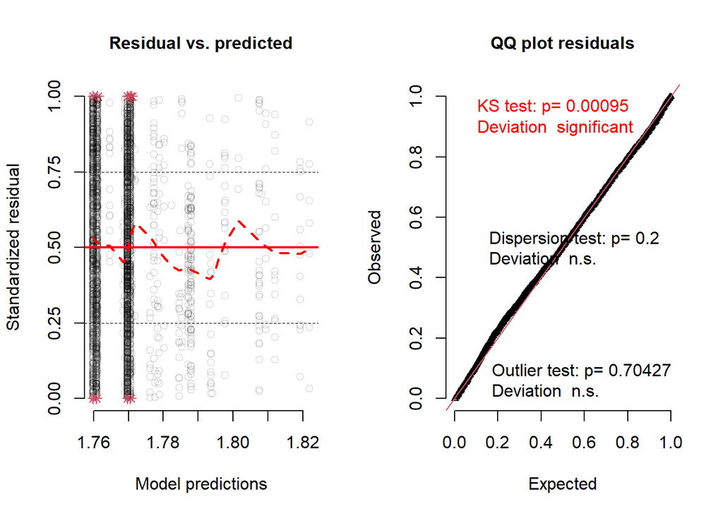

```
## Analysis of Deviance Table (Type II Wald chisquare tests)
##
## Response: sqrt(width)
##                 Chisq Df Pr(>Chisq)
## finch_beak     0.2415  1     0.6231
## year_collected 1.6943  1     0.1930
```

#### Emmeans: Width

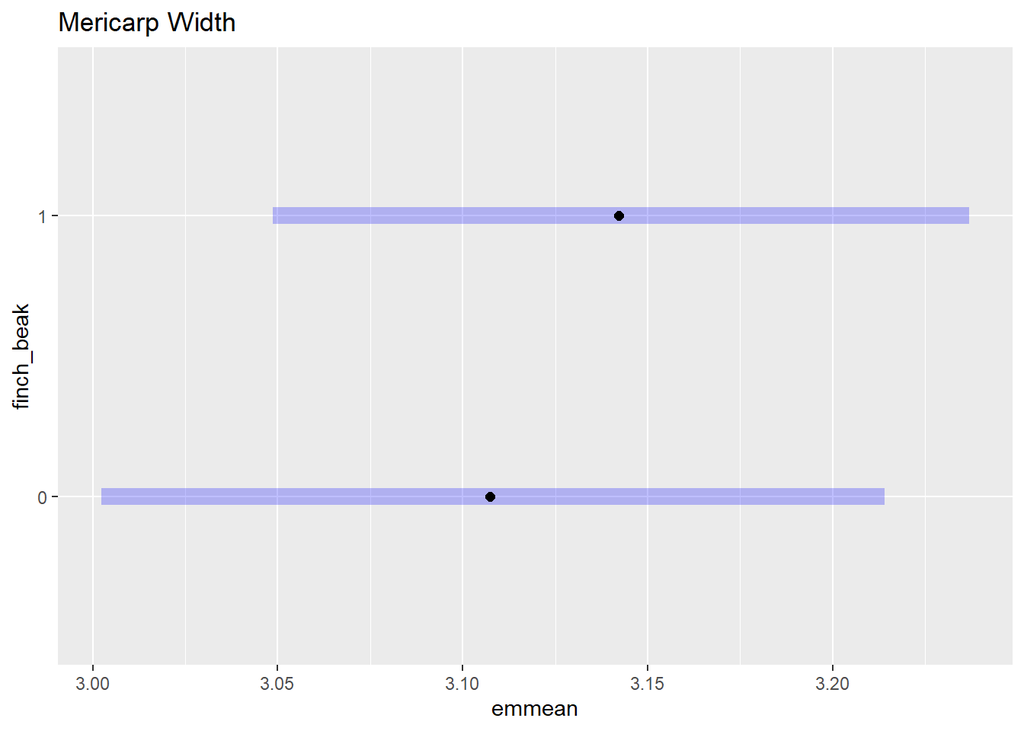

### Depth

Best fitted data: Untransformed data

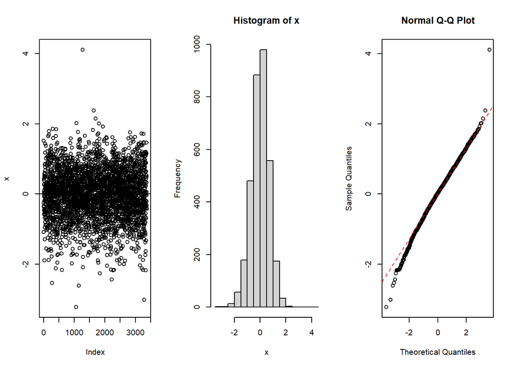

```
## [1] "Kurtosis=0.742071142705659"
## [1] "Skew=-0.204346797146509"
```

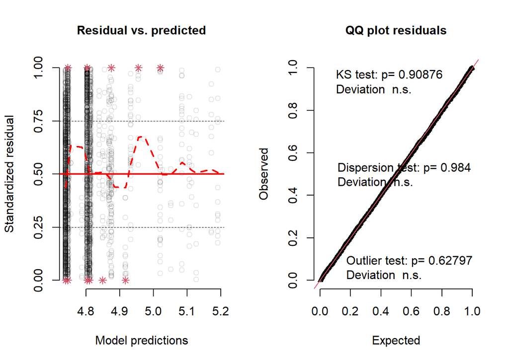

```
## Analysis of Deviance Table (Type II Wald chisquare tests)
##
## Response: depth
##                 Chisq Df Pr(>Chisq)
## finch_beak     0.4309  1    0.51155
## year_collected 4.1036  1    0.04279 *
## ---
## Signif. codes:  0 '***' 0.001 '**' 0.01 '*' 0.05 '.' 0.1 ' ' 1
```

#### Emmeans: Depth

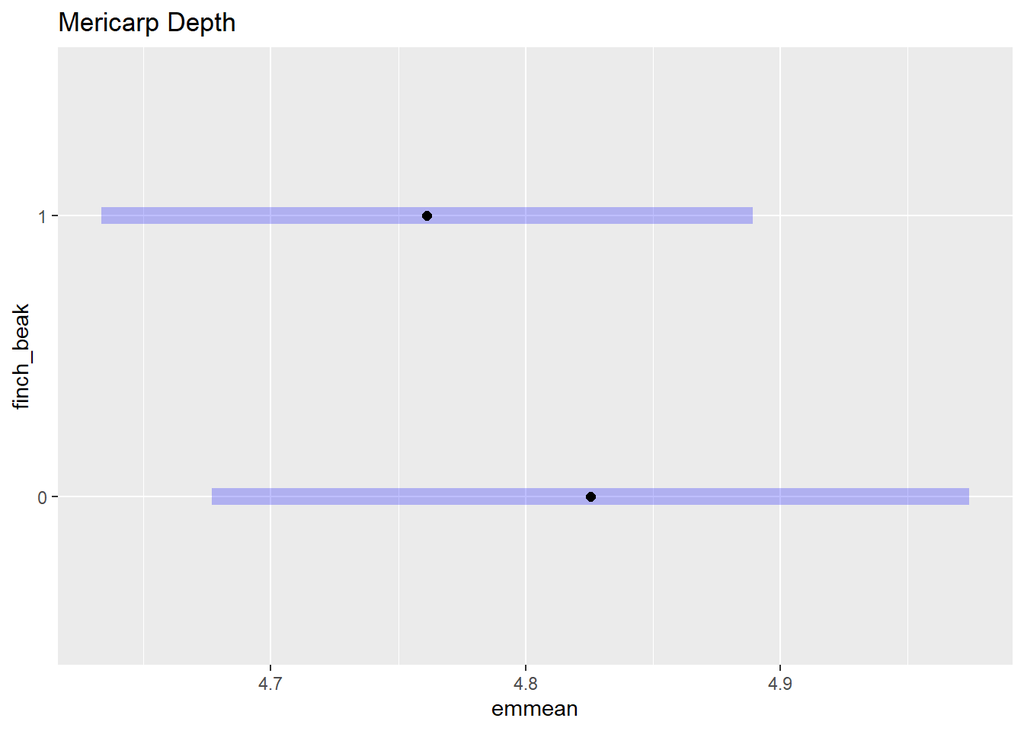

### Spine length

Spine length had a lot zeroes that were removed.

Best fitted data: Untransformed data.

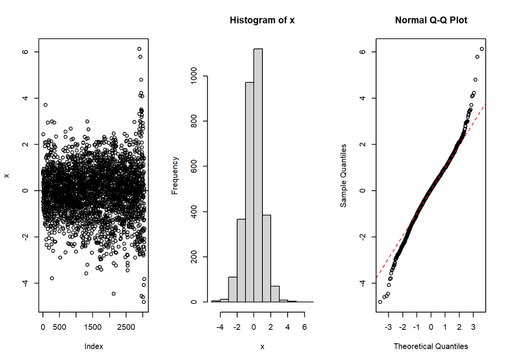

```
## [1] "Kurtosis=1.39547873017004"
## [1] "Skew=-0.109215601223584"
```

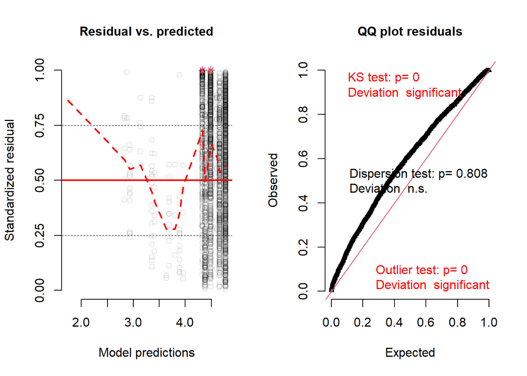

```
## Analysis of Deviance Table (Type II Wald chisquare tests)
##
## Response: spine_length
##                  Chisq Df Pr(>Chisq)
## finch_beak      1.8926  1     0.1689
## year_collected 17.4551  1  2.942e-05 ***
## ---
## Signif. codes:  0 '***' 0.001 '**' 0.01 '*' 0.05 '.' 0.1 ' ' 1
```

#### Emmeans: Spine length

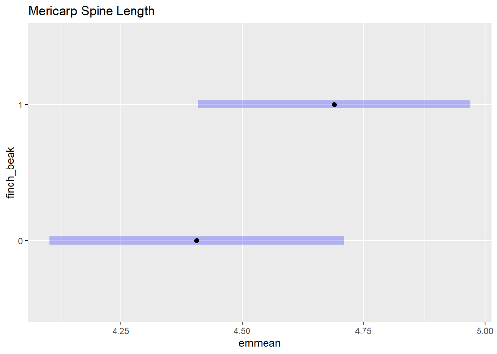

### Tip distance

The diagnostic function shows the residuals distribution after removing zeros and filtering residuals that were lower than -9.

Best fitted data: Untransformed data.

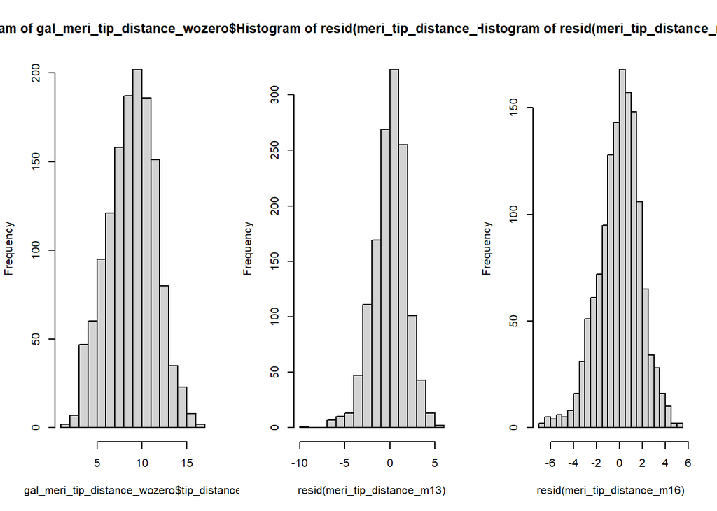

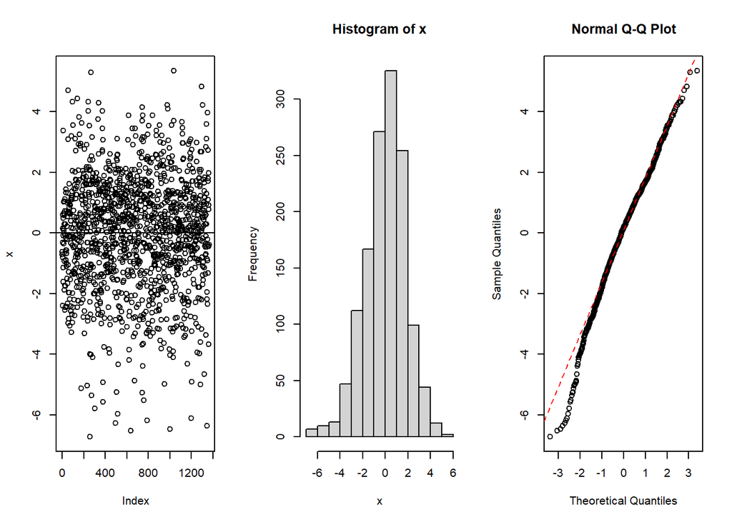

```
## [1] "Kurtosis=0.583306801964268"
## [1] "Skew=-0.428815505578938"
```

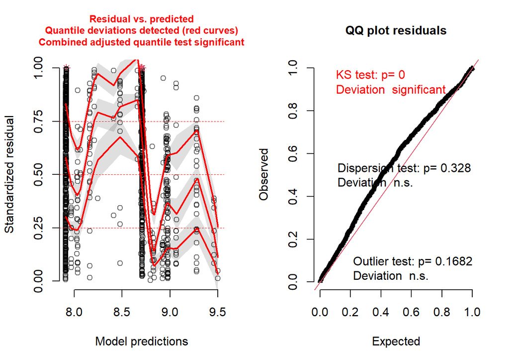

```
## Analysis of Deviance Table (Type II Wald chisquare tests)
##
## Response: tip_distance
##                 Chisq Df Pr(>Chisq)
## finch_beak     4.0870  1    0.04321 *
## year_collected 1.2434  1    0.26481
## ---
## Signif. codes:  0 '***' 0.001 '**' 0.01 '*' 0.05 '.' 0.1 ' ' 1
```

**Finch beak groups significant**

#### Emmeans: Tip distance

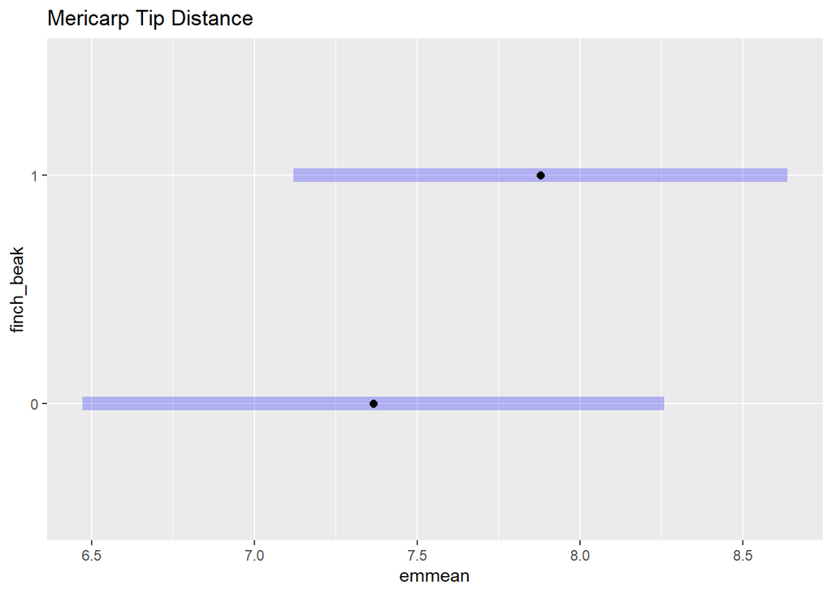

### Lower spines

Presence/absence of lower spines is a binomial trait for this one I used two models that showed different outcomes. The first one is a glm: **glm(lower_spines ~ mainland_island + year_collected)**.

This model includes year as a factor but does not contain ID as a random effect.

The second one using the *glmmTMB* package: **glmmTMB(lower_spines ~ mainland_island + (1|ID)**

The glmmTMB model does not include the year factor but does include the random ID effect.

```
## Analysis of Deviance Table (Type II tests)
##
## Response: lower_spines
##                LR Chisq Df Pr(>Chisq)
## finch_beak      214.413  1  < 2.2e-16 ***
## year_collected   26.534  1  2.589e-07 ***
## ---
## Signif. codes:  0 '***' 0.001 '**' 0.01 '*' 0.05 '.' 0.1 ' ' 1
```

```
## Analysis of Deviance Table (Type II Wald chisquare tests)
##
## Response: lower_spines
##             Chisq Df Pr(>Chisq)
## finch_beak 3.6226  1      0.057 .
## ---
## Signif. codes:  0 '***' 0.001 '**' 0.01 '*' 0.05 '.' 0.1 ' ' 1
```

#### Emmeans: Lower spines

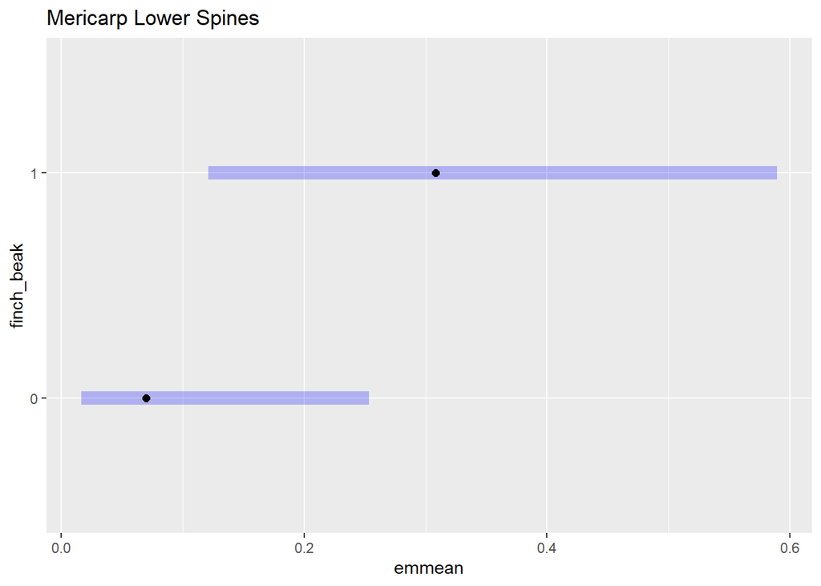

First plot, glm model. Second plot, glmmTMB model.

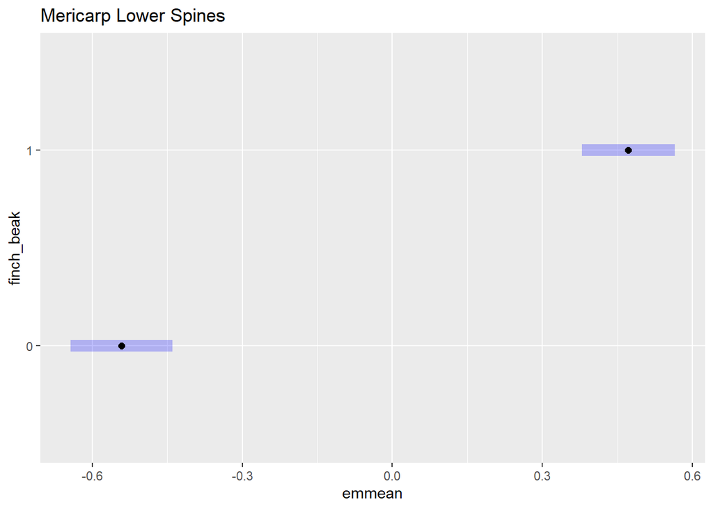

First plot, glm model. Second plot, glmmTMB model.

### Upper spines

Presence/absence of upper spines is a binomial trait that replaced spine number. Similar as lower spines, I used two models that showed different outcomes. The first one is a glm: **glm(upper_spines ~ mainland_island + year_collected)**.

This model includes year as a factor but does not contain ID as a random effect.

The second one using the *glmmTMB* package: **glmmTMB(upper_spines ~ mainland_island + (1|ID)**

The glmmTMB model does not include the year factor but does include the random ID effect.

[output not shown]

```
## Analysis of Deviance Table (Type II Wald chisquare tests)
##
## Response: upper_spines
##            Chisq Df Pr(>Chisq)
## finch_beak 0.138  1     0.7103
```

**Here, for the glm model the results are significant, but for the glmmTMB the differences between mainland and island populations are not signigicant.**

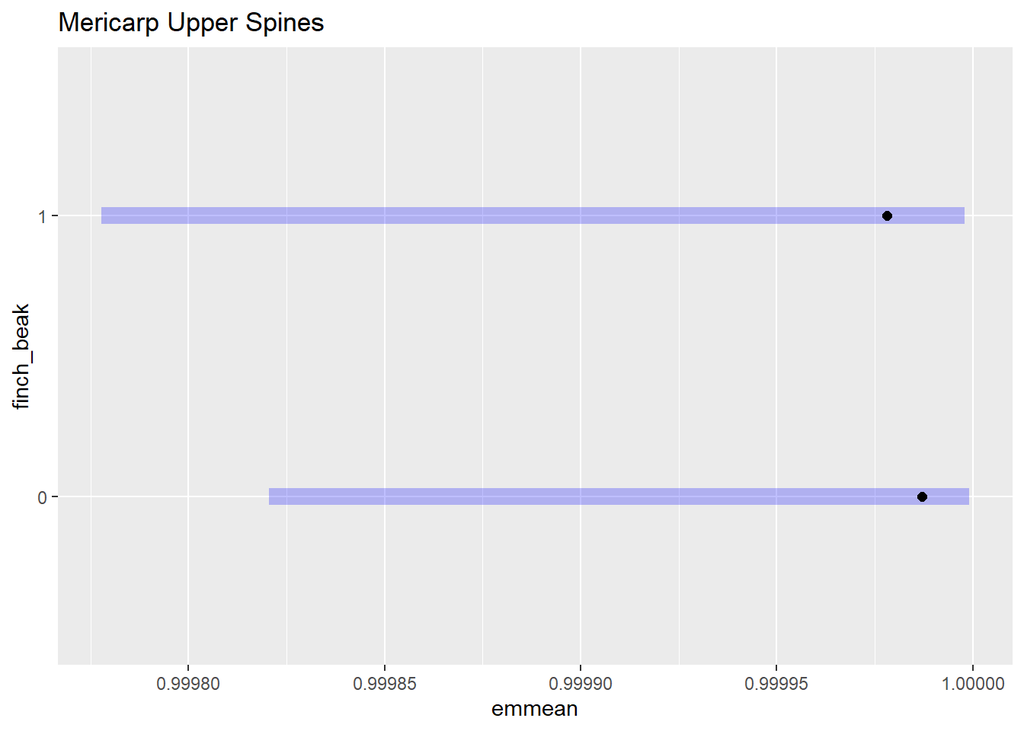

First plot, glm model. Second plot, glmmTMB model.

[figure not shown]

First plot, glm model. Second plot, glmmTMB model.

## Flower traits:

### Petal length

Best fitted data: Square root data

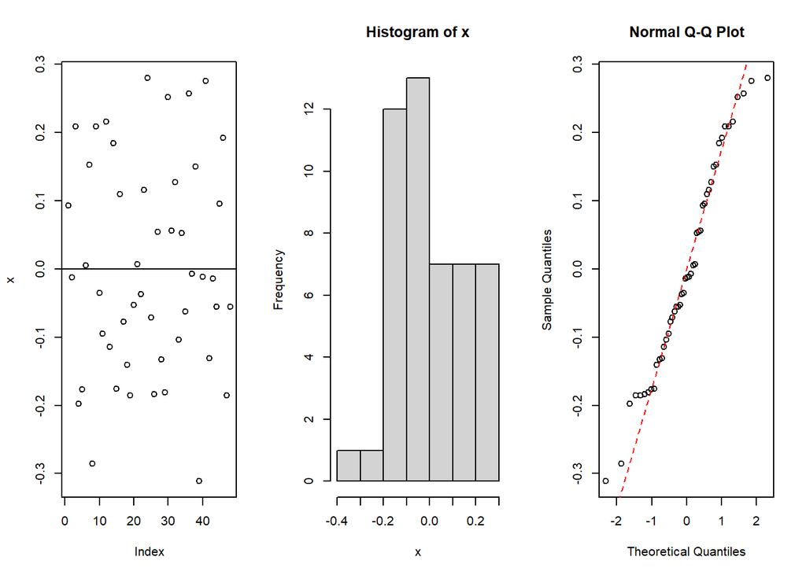

```
## [1] "Kurtosis=-0.984219631146156"
## [1] "Skew=0.122007465363433"
```

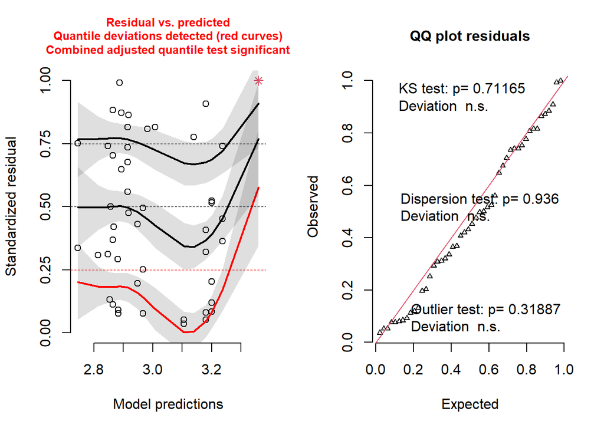

```
## Analysis of Deviance Table (Type II Wald chisquare tests)
##
## Response: sqrt(petal_length)
##                 Chisq Df Pr(>Chisq)
## finch_beak     0.3459  1   0.556418
## year_collected 6.7203  1   0.009532 **
## ---
## Signif. codes:  0 '***' 0.001 '**' 0.01 '*' 0.05 '.' 0.1 ' ' 1
```

**Year differences are significant.**

#### Emmeans: Petal length

[figure not shown]

## Leaf traits:

### Leaf length

Best fitted data: Square root transformed data

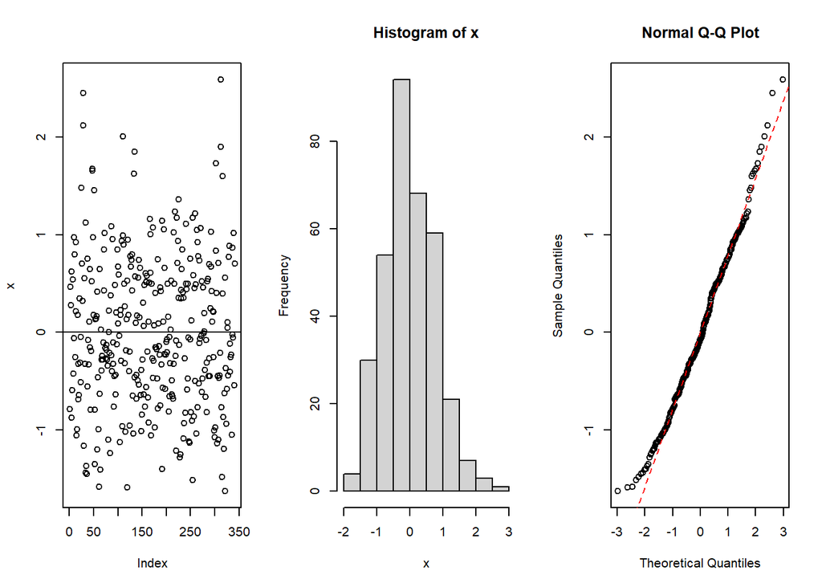

```
## [1] "Kurtosis=-0.016632520030861"
## [1] "Skew=0.32922404767702"
```

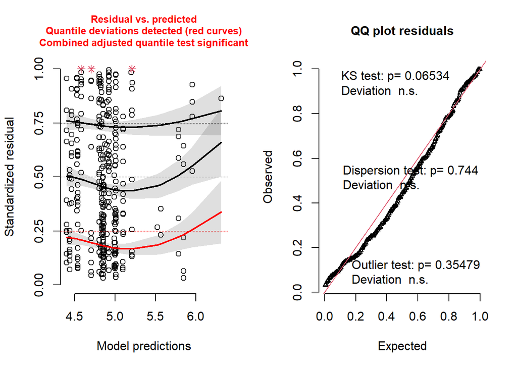

```
## Analysis of Deviance Table (Type II Wald chisquare tests)
##
## Response: sqrt(leaf_length)
##                  Chisq Df Pr(>Chisq)
## finch_beak      1.8787  1  0.1704780
## year_collected 12.8565  1  0.0003363 ***
## ---
## Signif. codes:  0 '***' 0.001 '**' 0.01 '*' 0.05 '.' 0.1 ' ' 1
```

**Year differences are significant.**

#### Emmeans: Leaf length

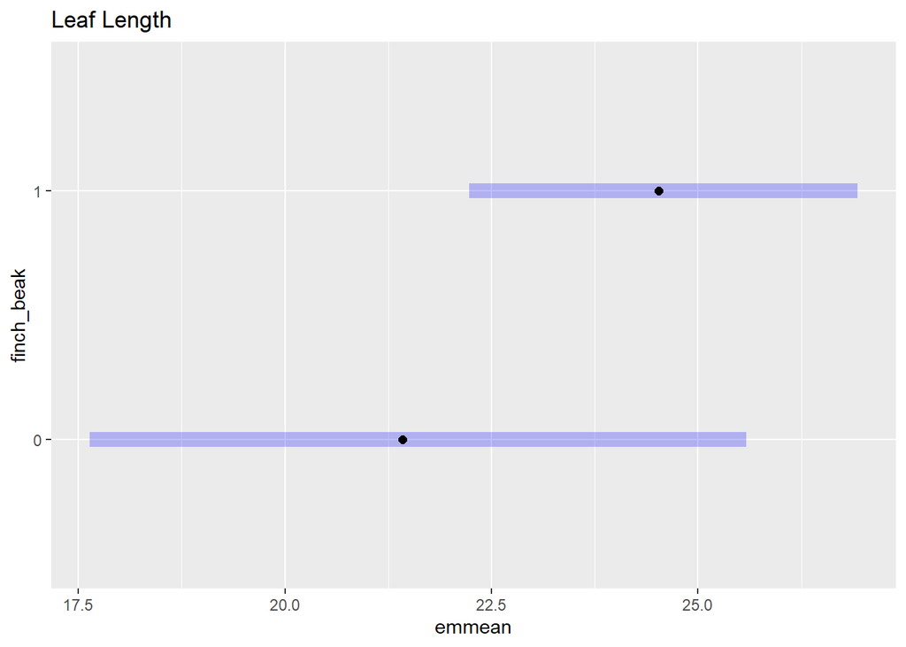

### Leaflet number

For this trait I used a glm model with a Poisson distribution:

**glm(number_of_leaflets ~ mainland_island + year_collected)**

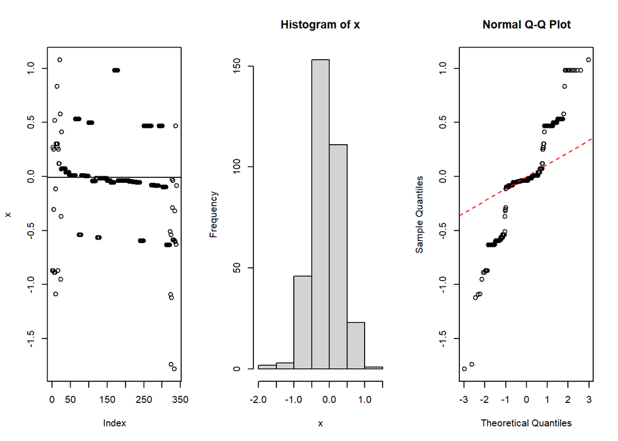

```
## [1] "Kurtosis=2.25505743315769"
## [1] "Skew=-0.393494785165159"
```

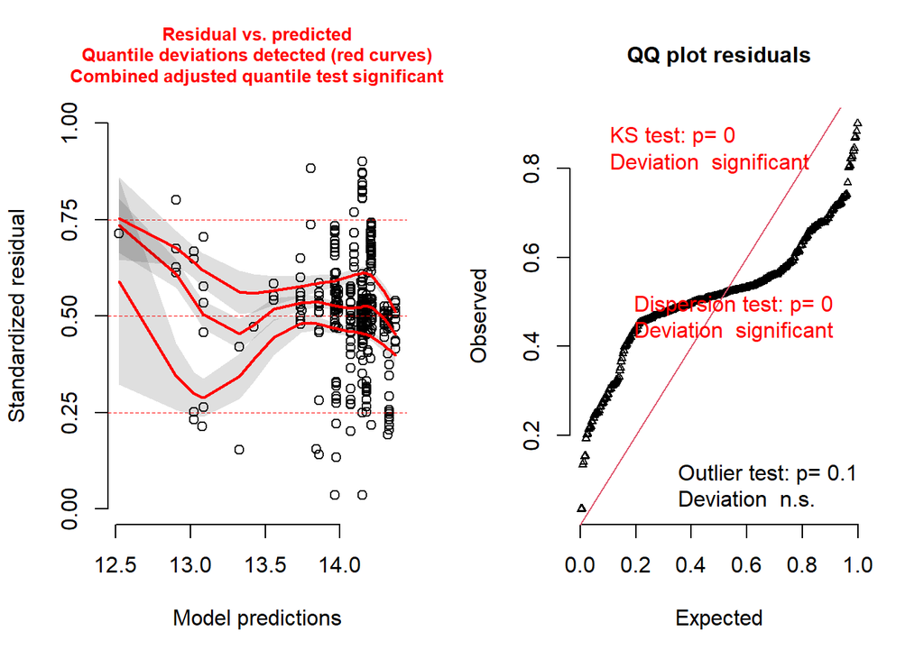

```
## Analysis of Deviance Table (Type II tests)
##
## Response: number_of_leaflets
##                LR Chisq Df Pr(>Chisq)
## finch_beak      0.01664  1     0.8974
## year_collected  1.94310  1     0.1633
```

#### Emmeans: Leaflet number

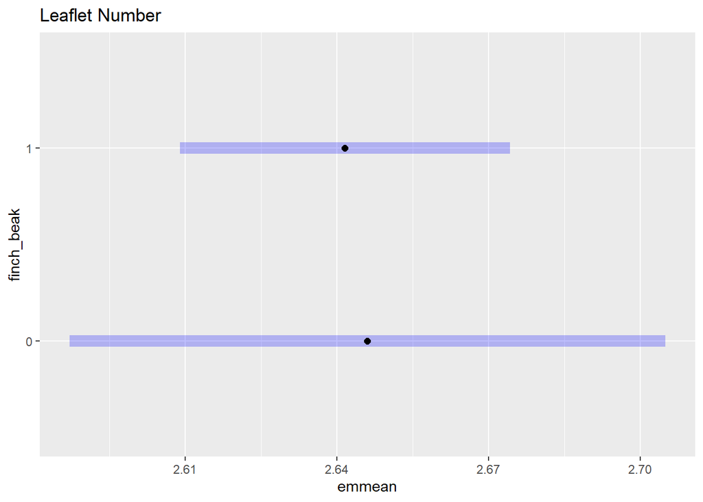

### Leaflet length

Best fitted data: Log transformed data

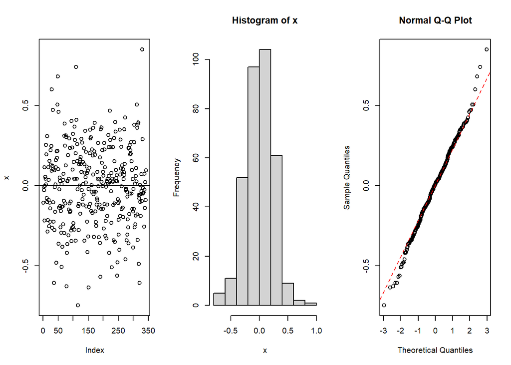

```
## [1] "Kurtosis=0.339413441190826"
## [1] "Skew=-0.0191508261482862"
```

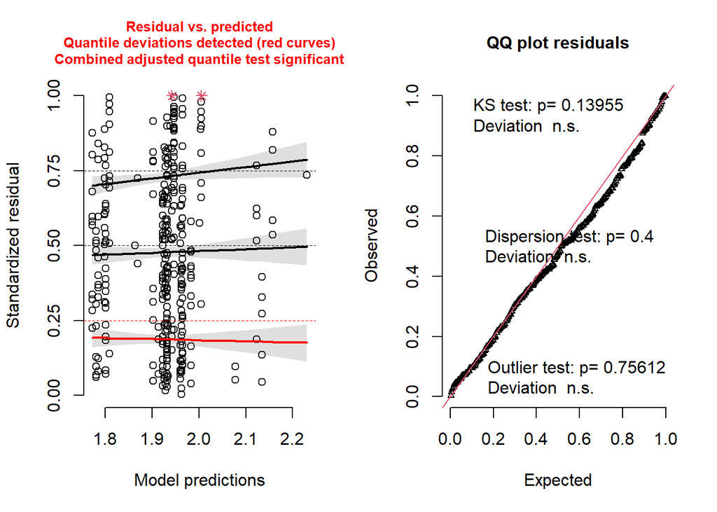

```
## Analysis of Deviance Table (Type II Wald chisquare tests)
##
## Response: log(leaflet_length)
##                 Chisq Df Pr(>Chisq)
## finch_beak     2.0280  1    0.15442
## year_collected 3.7091  1    0.05412 .
## ---
## Signif. codes:  0 '***' 0.001 '**' 0.01 '*' 0.05 '.' 0.1 ' ' 1
```

#### Emmeans: Leaflet length

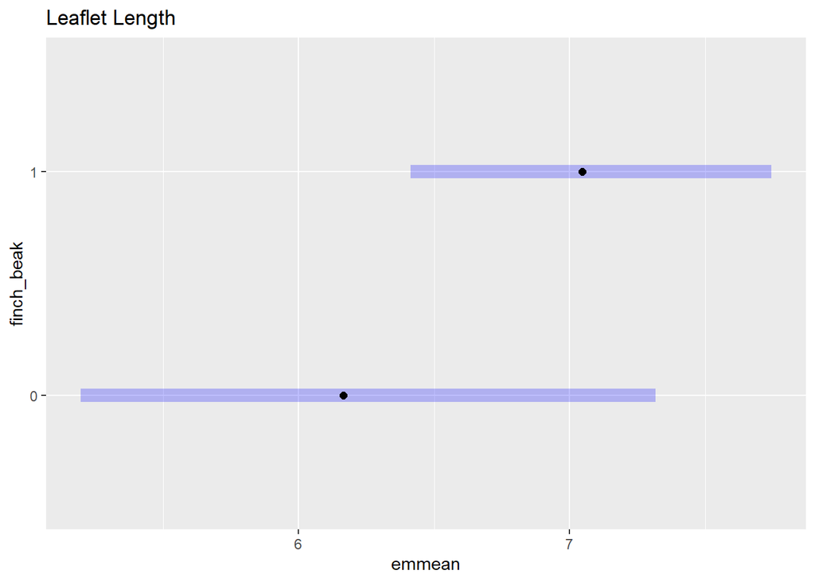